# (Carbon Dioxide Emissions)

## by Shrouk Reda

## Investigation Overview

> My goal is to discover the most important features that affects on the amount of carbon dioxide emissions from cars.

## Dataset Overview

> This dataset captures the details of how CO2 emissions by a vehicle can vary with the different features. The dataset has been taken from Canada Government official open data website. This is a compiled version. This contains data over a period of 7 years. There are total 7385 rows and 12 columns. There are few abbreviations that has been used to describe the features. I am listing them out in the next slide.

> Model 4WD/4X4 = Four-wheel drive AWD = All-wheel drive FFV = Flexible-fuel vehicle SWB = Short wheelbase LWB = Long wheelbase EWB = Extended wheelbase

> Transmission A = Automatic AM = Automated manual AS = Automatic with select shift AV = Continuously variable M = Manual 3 - 10 = Number of gears

> Fuel type X = Regular gasoline Z = Premium gasoline D = Diesel E = Ethanol (E85) N = Natural gas

> Fuel Consumption City and highway fuel consumption ratings are shown in litres per 100 kilometres (L/100 km) - the combined rating (55% city, 45% hwy) is shown in L/100 km and in miles per gallon (mpg)

> CO2 Emissions The tailpipe emissions of carbon dioxide (in grams per kilometre) for combined city and highway driving.

## (Relation between car make and Co2 emissions)

> **We can observe that most of the costly brand cars like BUGATTI and LAMBORGHINI are emmitting lot of carbon emissions and brands like HONDA and FIAT are least carbon emitting vehicles.**

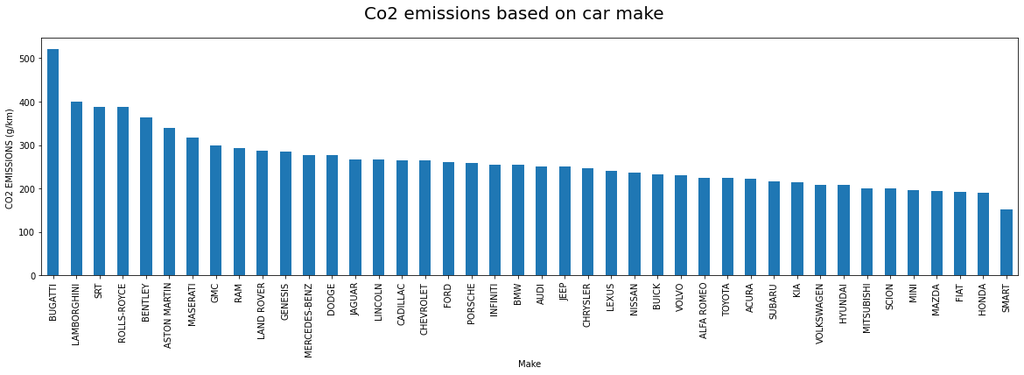

## (Relation between engine size and Co2 emissions)

> **We can observe that the larger the engine, the higher emissions of Co2.**

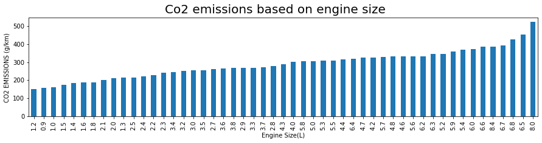

> **We can see that Large size engines consumes more fuel and emitt large amount of carbon emissions.**

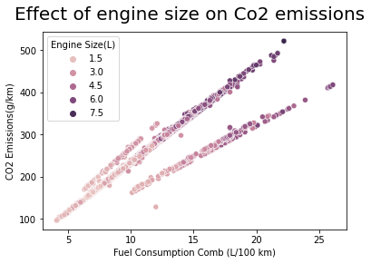

## (Relation between number of cylinders and Co2 emissions)

> **we can observe that the higher the number of cylinders, the higher the CO2 emissions.**

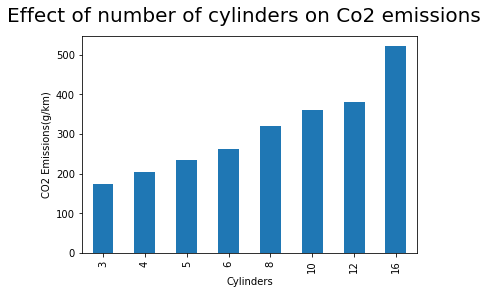

## Correlation Matrix

> Fuel Consumption Comb (mpg) is negatively correlated to all the features. Both Fuel Consumption City (L/100 km) and Fuel Consumption Hwy (L/100 km) have very strong positive correlation of 0.99 and 0.98 with Fuel Consumption Comb (L/100 km), since Fuel Consumption Comb (L/100 km) is redundant. CO2 Emissions(g/km) has highest positive correlation of 0.92 with Fuel Consumption City (L/100 km) and Fuel Consumption Comb (L/100 km) and negative correlation of -0.91 with Fuel Consumption Comb (mpg).

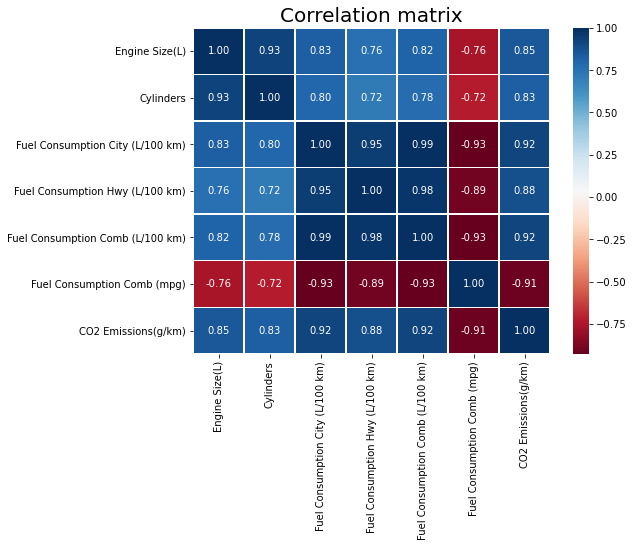